# Appendix: Sensitivity Analysis of Climate Vulnerability Indicators and Scores

DRAFT - not for further distribution without permission of the authors

Cory Lagasse, Josie Iacarella, Colin Bailey, Michael Arbeider, Timothy Healy

02 June 2026

# 1 Overview

This appendix describes the sensitivity analysis of the Climate Vulnerability Indicators for Salmon (CVIS) framework. The analysis evaluates how climate model uncertainty and methodological choices propagate into individual indicator values and aggregate vulnerability scores across the 50 Fraser River salmon conservation units (CUs) assessed in the main report. Results are presented in three sections:

1. **Indicator-Level Sensitivity** — variability of raw and standardized individual indicator values across climate scenarios, GCMs, and downscaling methods.
2. **Overall and Category Vulnerability Sensitivity** — how uncertainty in indicator inputs propagates into final vulnerability scores and CU rankings for each life-stage category and the overall vulnerability score.
3. **Drivers of Vulnerability Variation** — multivariate analysis of the dominant factors explaining variation in overall vulnerability across CUs, including PCA-based risk profiling, factor importance, and SMU-level sensitivity to climate uncertainty.

## 1.1 Baseline Scenario

All deviations are expressed relative to a common **baseline scenario**: the **GCM ensemble mean** (GCM 9; mean of GCMs 1, 4, and 6) under **RCP 4.5** for the **mid-century period (2041–2060; Period 3)**. This is the same default scenario presented in the main report. Category and overall scores use the **average scoring method** (`avg` for life-stage categories; `catavg` for overall vulnerability) as the baseline method.

## 1.2 Sources of Variation

**Global Climate Model (GCM) Uncertainty**  
The sensitivity of indicators and scores to individual GCMs is evaluated by substituting the ensemble mean with each of three individual GCMs used across the freshwater and marine climate models in the CVIS framework. All other scenario parameters (RCP, period) are held at the baseline.

| Source label | GCM | Model name |
| --- | --- | --- |
| GCM1 | GCM 1 | CanESM2 |
| GCM4 | GCM 4 | HadGEM2-ES |
| GCM6 | GCM 6 | MPI-ESM-LR |

**Emissions Scenario and Time Period**  
The sensitivity of vulnerability scores to emission pathway and projection horizon is evaluated by substituting the baseline RCP 4.5, mid-century scenario with three alternative combinations of RCP and time period. All other parameters (GCM, method) are held at baseline.

| Source label | Emissions scenario | Time period |
| --- | --- | --- |
| RCP45_P5 | RCP 4.5 | End-of-century (2081–2099) |
| RCP85_P3 | RCP 8.5 | Mid-century (2041–2060) |
| RCP85_P5 | RCP 8.5 | End-of-century (2081–2099) |

**Downscaling Method**  
For indicators derived from statistically downscaled climate data (stream temperatures, flow metrics), multiple downscaling methods are available. The sensitivity of these indicators and their contribution to category scores is evaluated by comparing the baseline downscaling method to alternative methods available for those indicators.

| Source label | Description |
| --- | --- |
| dsmethod | Mean deviation when substituting the alternative statistical downscaling method |

| Source label | Method | Description |
| --- | --- | --- |
| cube | Cubic mean | Category scores use the cubic (power) mean of indicators, emphasizing high risk values |
| avgcube | Average-of-categories using cubic mean | Category scores from cubic mean, then averaged |
| flag | Logic model | Indicators are binned into risk classes using fixed thresholds; overall score uses logic rules |
| avgall | Average of all indicators | All indicators weighted equally regardless of category |

> **Note:** Indicator-level sensitivity covers GCM, scenario, and downscaling method variation. Scoring method variation is only relevant at the category and overall vulnerability level.

# 2 Section 1: Indicator-Level Sensitivity

This section evaluates the degree to which each of the 17 CVIS indicators varies across global climate models and emissions scenarios. Indicator-level sensitivity provides insight into which components of the vulnerability assessment are most exposed to climate model uncertainty, and in which direction those indicators are projected to shift under different climate futures.

- **Mean Absolute Deviation (MAD):** The average of |indicator value – baseline value| across all CUs for a given source of variation. Larger values indicate greater sensitivity, regardless of direction.
- **Mean Raw Deviation:** The average of (indicator value – baseline value) with sign retained. Positive values indicate that the indicator increases (higher risk) relative to baseline; negative values indicate a decrease (lower risk).
- **Mean Rank Displacement (MRD):** The average absolute shift in the rank order of CU indicator values compared to the baseline ranking. An MRD of 0 means no change in the relative ranking of CUs; larger MRD indicates that the variation source disrupts the ordering of CUs.

## 2.1 Mean Absolute Deviation by Indicator and Source of Variation

The following plot summarizes the mean absolute deviation of each indicator across all CUs for each source of climate variation. Indicators are grouped by life-stage category and ordered by their overall sensitivity (mean MAD across sources). Larger bars indicate higher sensitivity of the indicator to the specified source of variation.

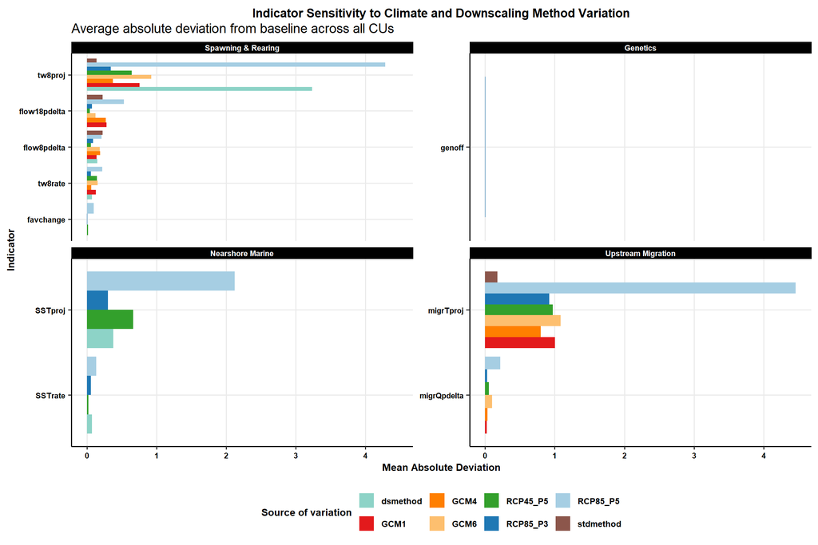

Mean absolute deviation of each CVIS indicator from the baseline scenario across all Conservation Units. Bars are grouped by source of variation and ordered by mean sensitivity within each life-stage category.

## 2.2 Directional Shifts: Baseline vs. Climate Scenarios

This visualization helps identify whether indicator responses are consistent across CUs (narrow error bars) or highly variable across the landscape (wide bars), and whether all GCMs agree in direction (consistent horizontal displacement) or show spread (overlapping error bars between sources).

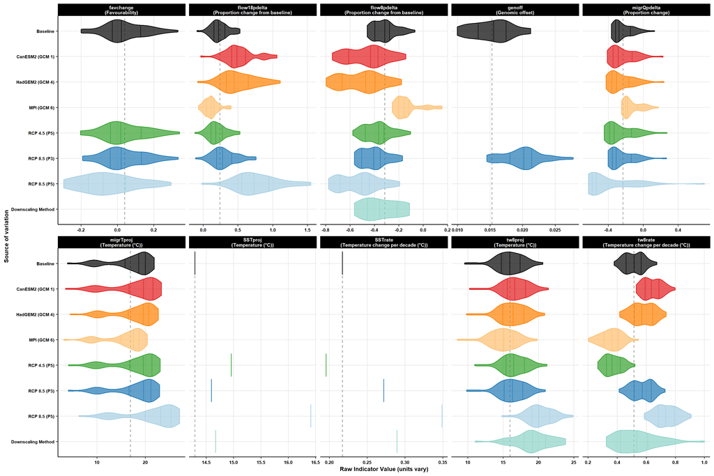

Directional shifts in indicator values relative to the categorical baseline (dashed vertical line) for each source of climate variation. Violins show density across Conservation Units.

## 2.3 Indicator Sensitivity Summary Table

The following table summarizes the mean raw deviation (Raw) and mean rank displacement (MRD) for each indicator and each source of variation. MRD represents how much the ranking of CUs for that indicator shifts relative to the baseline under each source of variation. Hyphen (—) indicates the source of variation is not applicable to the indicator (e.g., GCMs do not apply to non-climate indicators).

**Table A1. Summary of Indicator-Level Sensitivity Analysis**

Mean raw deviation and mean rank displacement (MRD) from the baseline scenario (RCP 4.5, mid-century, GCM ensemble mean). Raw values in standardized units; MRD in rank positions.<sup>1</sup>

|  | Indicator description | CanESM2 (GCM 1) Raw | CanESM2 (GCM 1) MRD | HadGEM2 (GCM 4) Raw | HadGEM2 (GCM 4) MRD | MPI-ESM (GCM 6) Raw | MPI-ESM (GCM 6) MRD | RCP 8.5, mid-cent. Raw | RCP 8.5, mid-cent. MRD | RCP 4.5, end-cent. Raw | RCP 4.5, end-cent. MRD | Downscaling method Raw | Downscaling method MRD | GCM spread q10 | GCM spread q90 |
| --- | --- | --- | --- | --- | --- | --- | --- | --- | --- | --- | --- | --- | --- | --- | --- |
| Spawning & Rearing |  |  |  |  |  |  |  |  |  |  |  |  |  |  |  |
| favchange | Change in ENM favourability | — | — | — | — | — | — | -0.004 | 1.040 | -0.004 | 1.60 | — | — | — | — |
| cthr | Standardized cumulative threats | — | — | — | — | — | — | — | — | — | — | — | — | — | — |
| tw8rate | Rate of change in August Temperature (°C/decade) | 0.126 | 2.92 | 0.062 | 4.88 | -0.154 | 3.36 | 0.057 | 1.640 | -0.142 | 2.16 | 0.019 | 7.640 | -0.111 | 0.113 |
| tw8proj | Projected August Temperature (°C) | 0.757 | 0.60 | 0.372 | 1.20 | -0.923 | 0.72 | 0.342 | 0.200 | 0.641 | 1.00 | 3.207 | 7.080 | -0.664 | 0.680 |
| flow8pdelta | Proportional change in August flow | -0.141 | 4.84 | -0.188 | 3.88 | 0.186 | 11.52 | -0.088 | 2.480 | -0.056 | 1.68 | -0.038 | 18.242 | -0.179 | 0.121 |
| flow18pdelta | Proportional change in Nov-Jan flow | 0.283 | 4.28 | 0.270 | 3.12 | -0.123 | 6.84 | 0.066 | 3.800 | -0.041 | 2.08 | — | — | -0.044 | 0.280 |
| fwres | Freshwater residency time (days) | — | — | — | — | — | — | — | — | — | — | — | — | — | — |
| Upstream Migration |  |  |  |  |  |  |  |  |  |  |  |  |  |  |  |
| migrTproj | Projected temperature during upstream migration (°C) | 0.975 | 0.48 | 0.798 | 0.88 | -1.086 | 0.84 | 0.921 | 0.240 | 0.971 | 0.48 | — | — | -0.709 | 0.940 |
| migrQpdelta | Proportional change in discharge | -0.005 | 0.92 | -0.020 | 0.56 | 0.102 | 3.76 | -0.012 | 0.720 | -0.028 | 1.00 | — | — | -0.017 | 0.081 |
| migrdist | Length of upstream migration (km) | — | — | — | — | — | — | — | — | — | — | — | — | — | — |
| Nearshore Marine |  |  |  |  |  |  |  |  |  |  |  |  |  |  |  |
| SSTproj | Projected nearshore SST (°C) | — | — | — | — | — | — | 0.302 | 0.000 | 0.665 | 0.00 | 0.379 | 0.000 | — | — |
| SSTrate | Rate of change in nearshore SST (°C/decade) | — | — | — | — | — | — | 0.055 | 0.000 | -0.021 | 0.00 | 0.072 | 0.000 | — | — |
| CImpact | Cumulative impacts to habitat | — | — | — | — | — | — | — | — | — | — | — | — | — | — |
| Demographics |  |  |  |  |  |  |  |  |  |  |  |  |  |  |  |
| CUstatus | Wild Salmon Policy CU status | — | — | — | — | — | — | — | — | — | — | — | — | — | — |
| CUnmat | Number of mature individuals (spawners) | — | — | — | — | — | — | — | — | — | — | — | — | — | — |
| Genetics |  |  |  |  |  |  |  |  |  |  |  |  |  |  |  |
| hetzyg | Genetic heterozygosity | — | — | — | — | — | — | — | — | — | — | — | — | — | — |
| genoff | Genomic offset | — | — | — | — | — | — | 0.005 | 3.071 | — | — | — | — | — | — |

<sup>1</sup> Raw: mean raw deviation from baseline (positive = higher risk). MRD: mean rank displacement (higher = more reordering of CUs). GCM spread: 10th and 90th percentile of raw deviation across the three GCMs.

## 2.4 Indicator Collinearity

The Pearson correlation matrix below characterizes the degree of collinearity among standardized indicator values across all CUs using the baseline scenario. Strongly correlated indicators may provide redundant information when combined into category and overall vulnerability scores. Pie-style cells indicate the strength and direction of correlation: filled clockwise = positive correlation, counter-clockwise = negative.

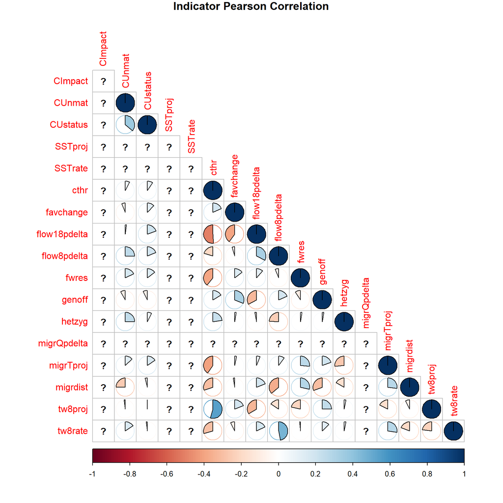

Pearson correlation matrix of standardized CVIS indicator values across all Fraser Basin CUs under the baseline scenario (RCP 4.5, mid-century, GCM ensemble mean). Pie area represents correlation magnitude; direction indicates the sign.

# 3 Section 2: Overall and Category Vulnerability Sensitivity

1. **Directional deviations** — the distribution of vulnerability score changes (scenario score − baseline score) across all CUs for each source of variation, showing both the typical magnitude and direction of uncertainty.
2. **Mean Rank Displacement (MRD)** — the average absolute shift in CU vulnerability rank relative to the baseline, quantifying the degree to which different sources of variation would change conclusions about relative vulnerability among CUs.
3. **Rank consistency (Spearman correlation)** — the correlation between CU vulnerability ranks under each alternative scenario and the baseline, summarizing overall consistency of CU orderings.
4. **Jackknife leverage analysis** — a leave-one-out approach that identifies which individual indicators and life-stage categories have the greatest influence on overall vulnerability scores.

## 3.1 Directional Influence on Vulnerability Scores

The boxplots below show the distribution of raw score deviations ((scenario score − baseline score) on the 0–100 CVIS vulnerability scale) for each source of variation across all CUs, grouped by vulnerability category. Boxes that span predominantly above zero indicate that the source of variation systematically increases vulnerability relative to the baseline; boxes below zero indicate systematic decreases. The spread of the boxplot reflects variability in the response across CUs — wide distributions suggest that the direction and magnitude of change is highly CU-specific.

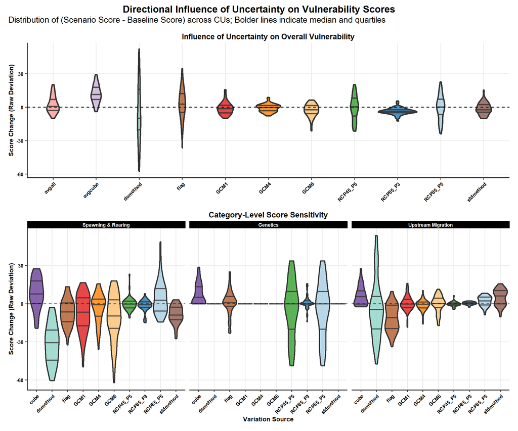

Distribution of raw vulnerability score deviations (scenario – baseline, on 0–100 scale) across all CUs for each source of variation. The top pane shows Overall Vulnerability, while bottom panes show key life-stage categories. Thicker internal lines represent the median and interquartile range (25th and 75th percentiles).

## 3.2 Mean Rank Displacement

Mean Rank Displacement (MRD) quantifies the average absolute change in the vulnerability rank of CUs compared to the baseline scenario ranking. An MRD of zero means the ranking of CUs is identical to the baseline; higher MRD values indicate greater disruption of the relative vulnerability ordering. MRD is particularly relevant for management applications where the ranking of CUs — rather than their absolute score — drives prioritization decisions.

### 3.2.1 Global Mean Rank Displacement

The following plot shows MRD for each source of variation across all CUs and all five species combined, grouped by vulnerability category. Sources of variation with higher MRD are those that most alter the relative standing of CUs.

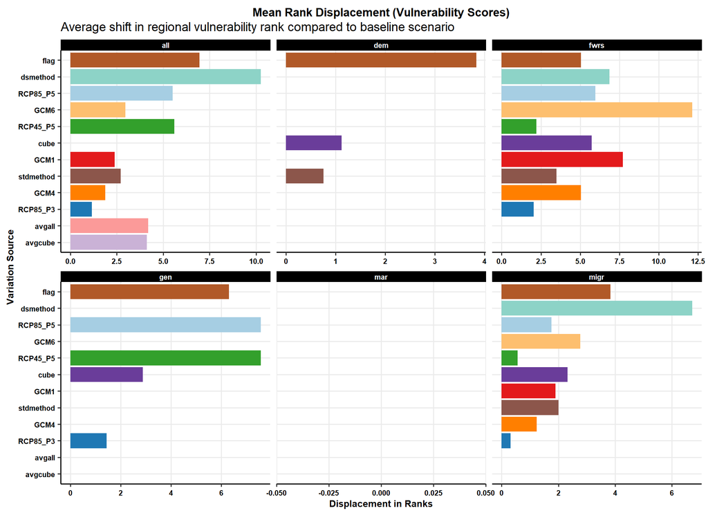

Mean rank displacement of CU vulnerability scores for each source of variation relative to the baseline scenario. Higher values indicate greater disruption of CU vulnerability rankings. Results are shown across all CUs and species combined.

## 3.3 Jackknife Leverage Analysis

The jackknife (leave-one-out) leverage analysis identifies which individual indicators and life-stage categories have the greatest influence on overall vulnerability scores. For each jackknife iteration, a single indicator or category is removed from the calculation, and the overall vulnerability score is recomputed across all CUs. The deviation between the jackknife score and the baseline score (with all indicators included) measures the “leverage” of that element.

A **negative mean raw deviation** after removing an element indicates that the element was contributing to **higher** overall vulnerability (i.e., removing it causes scores to decrease — the element is a risk driver). A **positive mean raw deviation** indicates the removed element was reducing overall scores (i.e., removing it causes scores to increase).

The leverage analysis thus identifies which indicators and categories are most important risk drivers for overall vulnerability, and which contribute least to distinguishing among CUs.

### 3.3.1 Global Jackknife Leverage (All CUs and Species)

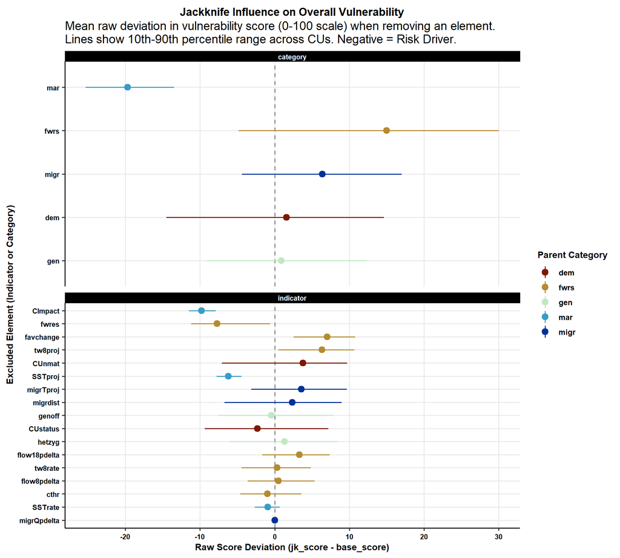

Jackknife leverage analysis for overall vulnerability (all CUs and species combined). Each point shows the mean raw deviation in overall vulnerability score (0–100 scale) when the indicated indicator or category is excluded from the scoring. Error bars span the 10th–90th percentile range across CUs. Negative values identify risk drivers; positive values indicate that an element suppresses overall scores. Elements are ordered by their mean absolute deviation (most influential at top).

## 3.4 Rank Consistency Heatmap

The Spearman rank correlation heatmap below summarizes the consistency of CU vulnerability rankings under each alternative scenario relative to the baseline and to each other. Each cell represents the pairwise Spearman correlation of CU ranks between two scenarios. Values close to 1.0 indicate that the ordering of CUs is nearly identical between scenarios; lower values indicate greater reordering. The heatmap reveals which combinations of variation sources produce the most similar — or most divergent — assessments of relative vulnerability.

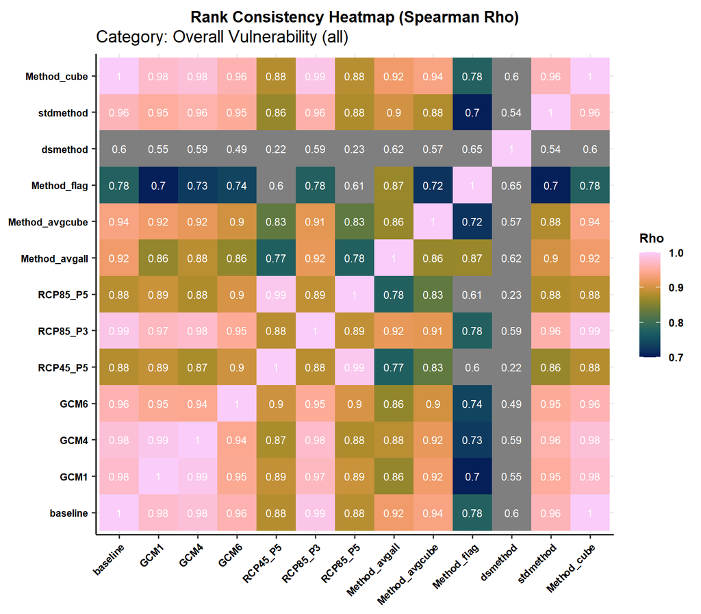

## 3.5 Vulnerability Score Sensitivity Summary Table

The following table provides a quantitative summary of sensitivity for each vulnerability category and the overall vulnerability score. For each source of variation we report the mean absolute deviation (Mean), 10th percentile (q10), and 90th percentile (q90) of absolute deviations across CUs (all on the 0–100 CVIS vulnerability scale), as well as the Spearman rank correlation (Rho) between the baseline and the alternative scenario. Higher absolute deviations and lower Rho values indicate greater sensitivity.

**Table A2. Vulnerability Score Sensitivity Summary**

Mean absolute deviation and Spearman rank correlation (Rho) relative to baseline (RCP 4.5, mid-century, GCM ensemble mean). Score deviations are on the 0–100 CVIS vulnerability scale.

| Vulnerability category | CanESM2 (GCM 1)<sup>1</sup> Mean | CanESM2 (GCM 1)<sup>1</sup> q10 | CanESM2 (GCM 1)<sup>1</sup> q90 | CanESM2 (GCM 1)<sup>1</sup> Rho | HadGEM2 (GCM 4)<sup>1</sup> Mean | HadGEM2 (GCM 4)<sup>1</sup> q10 | HadGEM2 (GCM 4)<sup>1</sup> q90 | HadGEM2 (GCM 4)<sup>1</sup> Rho | MPI-ESM (GCM 6)<sup>1</sup> Mean | MPI-ESM (GCM 6)<sup>1</sup> q10 | MPI-ESM (GCM 6)<sup>1</sup> q90 | MPI-ESM (GCM 6)<sup>1</sup> Rho | RCP 4.5, end-century<sup>1</sup> Mean | RCP 4.5, end-century<sup>1</sup> q10 | RCP 4.5, end-century<sup>1</sup> q90 | RCP 4.5, end-century<sup>1</sup> Rho | RCP 8.5, mid-century<sup>1</sup> Mean | RCP 8.5, mid-century<sup>1</sup> q10 | RCP 8.5, mid-century<sup>1</sup> q90 | RCP 8.5, mid-century<sup>1</sup> Rho | Downscaling method<sup>1</sup> Mean | Downscaling method<sup>1</sup> q10 | Downscaling method<sup>1</sup> q90 | Downscaling method<sup>1</sup> Rho | Std Method<sup>1</sup> Mean | Std Method<sup>1</sup> q10 | Std Method<sup>1</sup> q90 | Std Method<sup>1</sup> Rho | Scoring method (cubic mean)<sup>1</sup> Mean | … |
| --- | --- | --- | --- | --- | --- | --- | --- | --- | --- | --- | --- | --- | --- | --- | --- | --- | --- | --- | --- | --- | --- | --- | --- | --- | --- | --- | --- | --- | --- | --- |
| Overall Vulnerability | 4.29 | 0.65 | 8.26 | 0.98 | 2.85 | 0.42 | 6.01 | 0.98 | 4.77 | 0.75 | 9.62 | 0.96 | 8.52 | 0.42 | 18.06 | 0.88 | 4.09 | 0.94 | 6.98 | 0.99 | 22.51 | 4.80 | 43.43 | 0.60 | 4.38 | 1.05 | 8.80 | 0.96 | 0.00 | … |
| Demographics | 0.00 | 0.00 | 0.00 | 1.00 | 0.00 | 0.00 | 0.00 | 1.00 | 0.00 | 0.00 | 0.00 | 1.00 | 0.00 | 0.00 | 0.00 | 1.00 | 0.00 | 0.00 | 0.00 | 1.00 | 0.00 | 0.00 | 0.00 | 1.00 | 3.09 | 0.00 | 13.61 | 0.99 | 10.21 | … |
| Genetics | 0.00 | 0.00 | 0.00 | 1.00 | 0.00 | 0.00 | 0.00 | 1.00 | 0.00 | 0.00 | 0.00 | 1.00 | 16.92 | 0.00 | 35.50 | 0.61 | 3.25 | 0.00 | 9.85 | 0.98 | 0.00 | 0.00 | 0.00 | 1.00 | 0.00 | 0.00 | 0.00 | 1.00 | 7.84 | … |
| Nearshore Marine | 0.00 | 0.00 | 0.00 | NA | 0.00 | 0.00 | 0.00 | NA | 0.00 | 0.00 | 0.00 | NA | 0.02 | 0.02 | 0.02 | NA | 0.01 | 0.01 | 0.01 | NA | 1.28 | 1.28 | 1.28 | NA | 0.00 | 0.00 | 0.00 | NA | 3.20 | … |
| Spawning & Rearing | 13.19 | 2.83 | 26.27 | 0.79 | 8.87 | 1.36 | 20.30 | 0.90 | 16.86 | 3.23 | 37.23 | 0.47 | 3.50 | 0.41 | 6.10 | 0.97 | 3.39 | 0.46 | 8.24 | 0.98 | 31.47 | 9.22 | 51.66 | 0.87 | 8.89 | 1.50 | 16.10 | 0.94 | 11.98 | … |
| Upstream Migration | 4.34 | 0.45 | 10.55 | 0.98 | 3.11 | 0.13 | 6.28 | 0.99 | 4.89 | 0.10 | 10.44 | 0.97 | 1.25 | 0.03 | 3.15 | 1.00 | 0.92 | 0.02 | 1.94 | 1.00 | 18.37 | 1.84 | 36.14 | 0.82 | 6.39 | 0.17 | 12.17 | 0.98 | 6.88 | … |

<sup>1</sup> Mean, q10, q90: mean, 10th-, and 90th-percentile absolute deviation from baseline score across all CUs. Rho: Spearman rank correlation between baseline and alternative scenario CU rankings.

# 4 Species-Specific Sensitivity Analysis

The following section examines how individual CUs within **Chinook**, **Sockeye**, and **Coho** salmon respond to different sources of variation. These species have multiple CUs, enabling meaningful within-species rank comparisons. Pink and Chum are excluded as they contain only one or two CUs, making rank comparisons unsuitable.

## 4.1 CU Vulnerability Rank Stability (Bump Plots)

CUs clustered at the top (Rank 1 = Highest Risk) that remain there across all scenarios represent the most robustly high-risk units; CUs with highly crossed lines indicate that their relative vulnerability ranking is sensitive to climate and methodological assumptions.

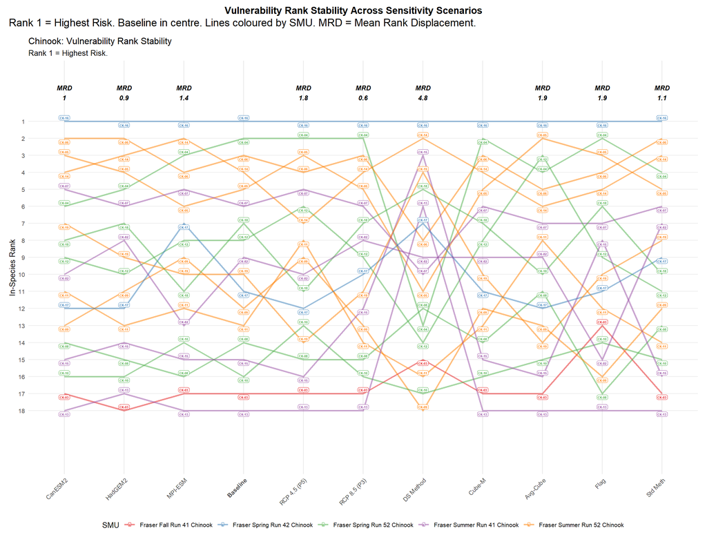

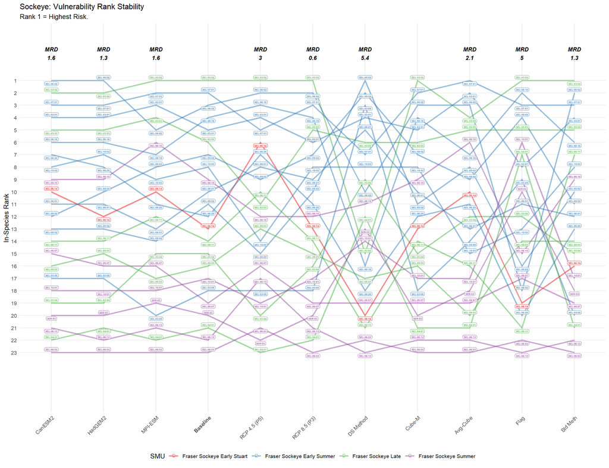

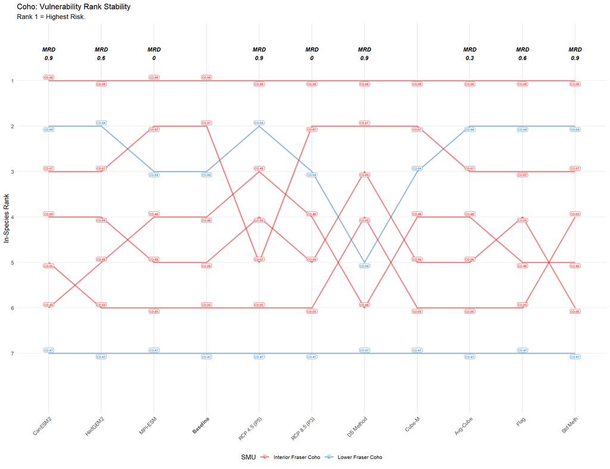

# 5 Section 3: Drivers of Vulnerability Variation

1. **Factor importance (ANOVA)** — identifies which fixed factors (species, management unit, climate cluster) statistically explain the largest proportion of variance in overall vulnerability.
2. **Vulnerability variation by SMU** — visualizes the distribution of baseline vulnerability scores within each Stock Management Unit, revealing which management units contain the most and least vulnerable CUs.
3. **SMU sensitivity to climate uncertainty** — shows how each SMU’s mean vulnerability score shifts in response to GCM and RCP variation.
4. **Multivariate risk profiling (PCA)** — a Principal Component Analysis of the baseline indicator profile for all CUs, revealing dominant axes of vulnerability and clustering of CUs by risk type.

## 5.1 Factor Importance

An ANOVA-based decomposition of variance in the overall baseline vulnerability score identifies which grouping factors (species, SMU, DFO area, indicator cluster groups) account for the greatest fraction of variability across CUs.

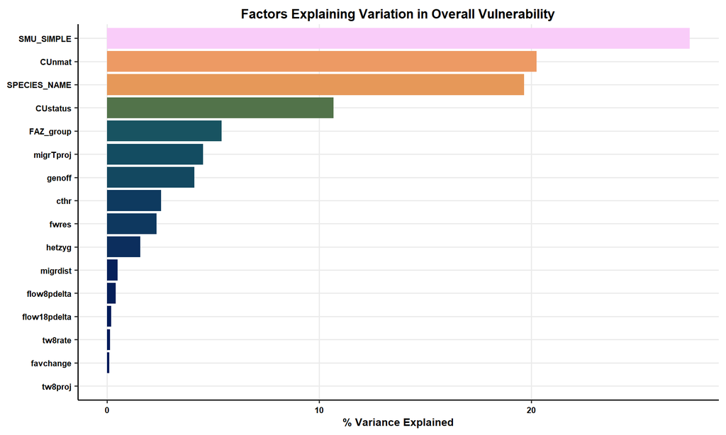

Percentage of variance in overall baseline vulnerability explained by each grouping factor, based on ANOVA decomposition. Factors are ordered by their contribution.

## 5.2 Vulnerability Variation by Stock Management Unit

The boxplots below show the distribution of baseline overall vulnerability scores (0–100 scale) for CUs within each Stock Management Unit (SMU), ordered by median vulnerability. Colour indicates species, allowing comparison of within-SMU and between-species patterns.

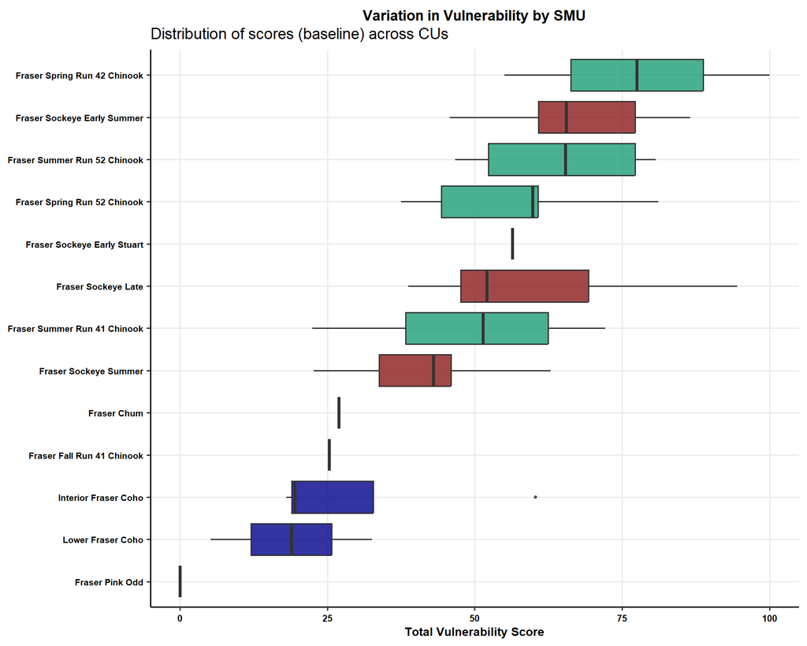

Distribution of baseline overall vulnerability scores across CUs within each Stock Management Unit (SMU), ordered by median score. Colour shows species. High-scoring SMUs contain CUs that are consistently more vulnerable under the baseline assessment.

## 5.3 SMU Sensitivity to Climate Uncertainty

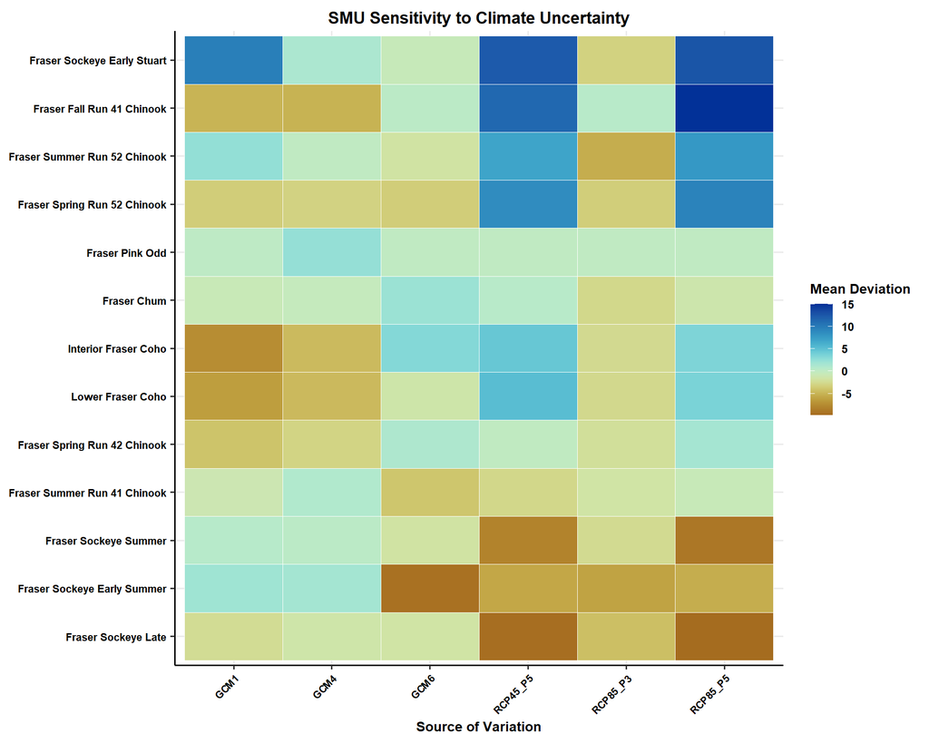

## 5.4 Multivariate Risk Profiling (PCA Biplot)

A Principal Component Analysis (PCA) was conducted on the standardized indicator values (baseline scenario) across all CUs. The biplot below shows each CU as a point (coloured by overall vulnerability score, shaped by species) and each indicator as an arrow (loading vector). Arrows pointing in similar directions indicate correlated indicators; the length and direction of each arrow reflects the indicator’s contribution to the principal components.

CUs clustered together share similar indicator profile (i.e., are vulnerable for similar reasons). The separation between species groups reveals the degree to which vulnerability pathways differ across salmon species in the basin.

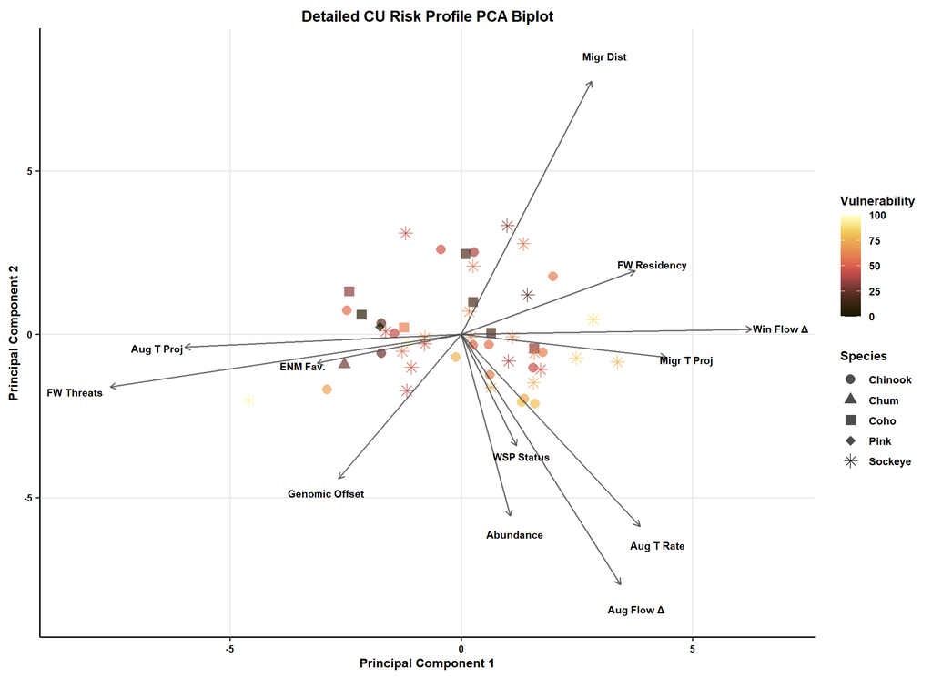

PCA biplot of baseline CU vulnerability profiles. Points represent CUs (colour = overall vulnerability score; shape = species). Arrows show indicator loadings — only indicators with loadings > 0.15 on PC1 or PC2 are labelled. CUs that cluster together share similar indicator-level risk profiles.

# 6 Section 4: Combined Uncertainty and Robustness Analysis

While the sensitivity analysis in previous sections evaluates shifts across discrete scenarios (holding other factors constant), the vulnerability assessment is subject to multiple simultaneous sources of uncertainty. To quantify how these uncertainties compound and propagate, a bootstrap uncertainty analysis was performed.

### 6.0.1 Bootstrapping Methodology

Under the bootstrap framework, we performed $B = 100$ iterations focusing on the mid-century period (Period 3: 2041–2060). For each iteration, we simultaneously and randomly sampled parameter configurations from the following uncertainty dimensions:

1. **Global Climate Models (GCMs):** Randomly sampled from the three common GCMs (`CanESM2`, `HadGEM2-ES`, and `MPI-ESM-LR`).
2. **Emissions Scenarios (RCPs):** Randomly sampled from `RCP 4.5` and `RCP 8.5`.
3. **Freshwater Temperature Downscaling:** Randomly sampled from `pcicgrid` (PCIC gridded downscaled temperature projections) and `tscapes` (Thermalscapes).
4. **Freshwater Flow Downscaling:** Randomly sampled from `station` (station-based downscaled flow projections) and `streamdyn` (dynamic streamflow modeling). Due to data constraints, when the `station` downscaling method is sampled, flow indicators default to the GCM ensemble mean (GCM 9) instead of the sampled individual GCM.
5. **Marine SST Downscaling:** Gridded sea surface temperature projections are randomly sampled from `qdm` (bias-corrected QDM) and `bccmssc` (spatial downscaling).

During this bootstrapping process, the following parameters were held fixed to ensure isolation of environmental uncertainty: - **Indicator Standardization:** Held fixed to the default standardization function and parameters for each indicator as defined in the CVIS configuration (`tbl_indicators`/`tbl_standardize`). Continuous indicators were not switched between linear and exponential risk curves. - **Aggregation and Scoring Method:** Held fixed to the baseline scoring configurations (`avg` for category-level aggregation; `catavg` for overall vulnerability score calculation). - **Vulnerability Score Scaling:** All re-computed overall vulnerability scores were scaled to the 0–100 range using fixed bounds derived from the baseline scenario distribution across all CUs.

This section presents:

1. **Combined Score Spread** — the overall variation in vulnerability scores (0–100 scale) for each CU across all iterations.
2. **Rank Uncertainty & Robustness Profiles** — the stability of CU vulnerability rankings and classification of CUs into robustness categories (Robust High, Robust Low, Highly Uncertain).
3. **Variance Decomposition (ANOVA)** — the relative contribution of each source of uncertainty to the total score variance.

## 6.1 Combined Score Spread

The boxplots below show the spread of overall CVIS vulnerability scores across the bootstrap iterations for each of the 50 CUs. CUs are ordered by their mean score. The horizontal spread of each box reflects the combined sensitivity of that CU to the joint uncertainty in climate projections and downscaling methodologies.

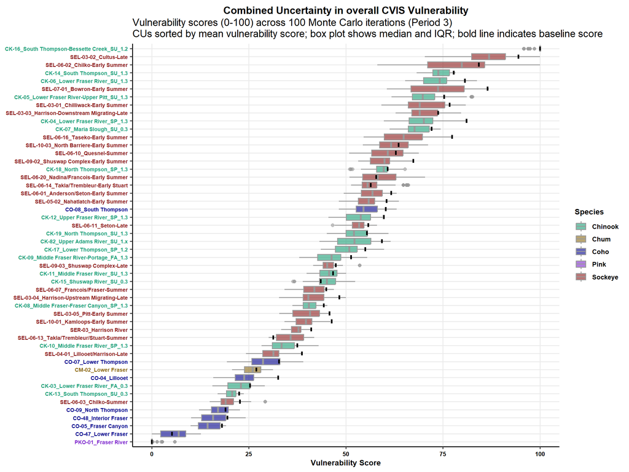

Distribution of overall CVIS vulnerability scores (0-100 scale) across bootstrap iterations for each Fraser River salmon Conservation Unit. CUs are colored by species and sorted by their mean vulnerability score.

## 6.2 Rank Uncertainty & Robustness Profiles

While score spreads indicate absolute sensitivity, management decisions often depend on the relative priority or ranking of CUs. The plot below displays the mean vulnerability rank and 90% confidence intervals (5th to 95th percentiles) across the iterations. CUs are colored by their robustness profile, which categorizes them as: - **Robust High** (consistently high risk; 5th percentile score >= 50) - **Robust Low** (consistently low risk; 95th percentile score <= 35) - **Highly Uncertain** (large variation; score range >= 25 or rank range >= 15 ranks) - **Intermediate / Moderate** (moderate risk with stable to semi-stable rankings)

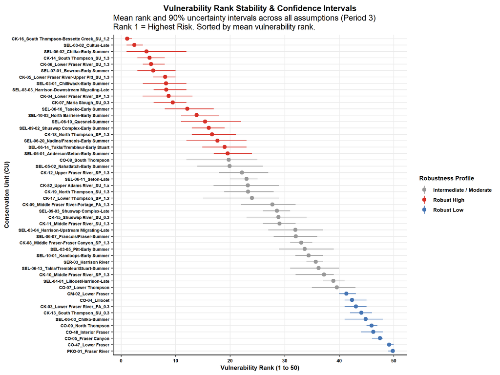

Mean vulnerability rank and 90% uncertainty intervals across all iterations. Rank 1 indicates highest vulnerability. CUs are color-coded by their robustness profile.

## 6.3 Variance Decomposition (ANOVA)

To identify which uncertainty sources contribute the most to the variation in final vulnerability scores, a multi-way Analysis of Variance (ANOVA) was performed on the bootstrap score outputs. The linear model includes `FULL_CU_IN` as a factor to control for the baseline geographical and biological differences among CUs. The remaining variance is then decomposed into the relative contributions of the sampled uncertainty parameters: - Global Climate Model (`sampled_gcm`) - Emission Scenario (`sampled_rcp`) - Temperature Downscaling Method (`sampled_ds_temp`) - Flow Downscaling Method (`sampled_ds_flow`) - Marine Downscaling Method (`sampled_ds_mar`)

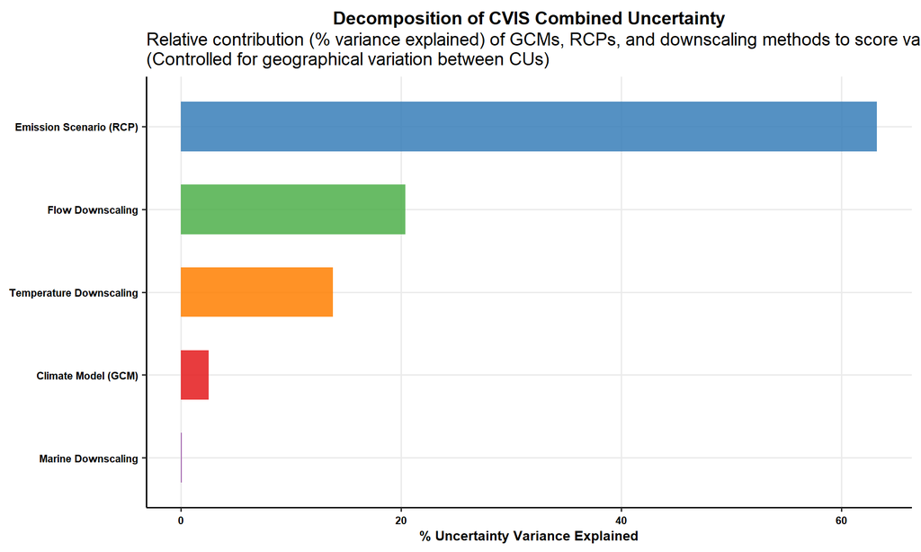

Decomposition of combined uncertainty variance. Bars represent the percentage of score variance explained by each source of variation after controlling for spatial differences among CUs.

# 7 Methods Summary

## 7.1 Analysis Scripts

The sensitivity analysis is implemented across the following scripts in the CVIS pipeline:

[output not shown]

## 7.2 Scoring Methods

Five scoring methods are evaluated in the sensitivity analysis at the category and overall vulnerability level:

| Method code | Description |
| --- | --- |
| `avg` / `catavg` | **Baseline method.** Category scores = arithmetic mean of standardized indicator values; overall = average of category scores |
| `cube` | Category scores = cubic (power) mean of indicators; emphasizes high values |
| `avgcube` | Category scores from cubic mean, then averaged across categories |
| `avgall` | All indicators weighted equally regardless of category (no category aggregation step) |
| `flag` | Logic model: indicators binned to low/moderate/high (thresholds at 0.33 and 0.66); overall score from logic rules |

## 7.3 Standardization and Score Scaling

Indicator standardization is applied **within each unique combination of GCM, RCP, time period, and downscaling method**, ensuring that the 0–1 standardization range is consistent for each climate scenario. This avoids conflating differences in absolute indicator magnitude with differences in relative rank within a scenario.

All vulnerability scores in the sensitivity analysis are scaled to a **0–100 scale** using fixed bounds derived from the **baseline scenario distribution** across all CUs. This ensures that deviations from the baseline accurately reflect shifts on a consistent vulnerability scale, rather than being re-scaled within each iteration.